# Stress-Prospection-Intertemporal Choice: Study 2 Analysis

Hayoung Ahn

May 2021 (last updated June 2021)

## 1. Introduction

This study looks at the effects of stress on our ability to imagine our personal future and make decisions that impact that future. Through the Trier Social Stress Test and an “Imagine” cue that prompts participants to prospect about their future, we are curious to see whether stress interacts with memory to influence the decisions you make during intertemporal choice.

First, let’s load in the data collected from Cognition.run (downloaded as .csv files from jsPsych task code). We’ll create one big dataframe (called `bigdf`) that appends all participants’ data together into matching columns.

48 participants were enrolled in the study; 8 participants were excluded due to no-shows/cancellations or incomplete data. Hence, 40 participants are included in this study sample.

```r
# Load subjects' data ------------------------------------------------
setwd('~/Box Sync/Bakkour-Lab/users/hayoung/stress_prospection_data/SONA_study2')
myfiles = list.files(path = "data", pattern = "*.csv", full.names=TRUE) #create a vector of file names to read in
bigdf = ldply(myfiles, read.csv)

#bigdf$choselater
bigdf$choselater[bigdf$ttype == 'choice' & bigdf$key_press == 75] <- 1
bigdf$choselater[bigdf$ttype == 'choice' & bigdf$key_press == 74] <- 0

write.csv(bigdf,'~/Box Sync/Bakkour-Lab/users/hayoung/stress_prospection_data/SONA_study2/bigdf.csv')

# Specify which subjects had their Session 1 = Stress
subsstressfirst = c(1,2,5,8,15,16,17,18,20,21,25,30,33,35,37,39,41,42,45,46,47)
```

## 2. Fitting hyperbolic discounting function (k)

### Define the function

In order to develop a measure of “impulsivity” with intertemporal choice, we estimated the individual k-values (discounting parameter) while assuming hyperbolic discounting. We followed the tutorial here: http://alexanderfengler.github.io/neuroeconomics/K-Estimation/.

```r
# Create hyperbolic discounting functions (k) ---------------------------------
## for a single choice
GetPChoice = function(k,sir,ldr,delay,choice) {
  if (choice == 75) {
    pchoice = exp(ldr/(1 + k*delay)) / (exp(sir) + exp(ldr/(1 + k*delay)))
  } else if (choice == 74) {
    pchoice = (1 -  (exp(ldr/(1 + k*delay)) / (exp(sir) + exp(ldr/(1 + k*delay)))))
  }
  return(pchoice)
}

# generate log likelihood (negative log to find minimization)
## iterating over trials
# sum negative log likelihoods to end up with a final likelihood for a given k
GenerateLogLik = function(cur_k){
  choiceprobs=rep(0,length(df$choice))
  for (i in 1:length(df$choice)){
    choiceprobs[i]=GetPChoice(cur_k,df$sir[i],df$ldr[i],df$delay[i],df$choice[i])
  }
  sumloglik = (-1)*(sum(log(choiceprobs)))
  if (sumloglik==Inf){
    sumloglik = 99999 #issue if this equals Inf
  }
  else {
    return(sumloglik)
  }
}
```

### Apply function to calculate individual k’s

```r
## Start big iterative for loop here ---------------------------------

# subset the amountlater/delay/choice for subject 1 session 1
# get k's from the function, and save out to a new dataframe (subject, session, k-value)

# define empty dataframe with three columns for iteration, group, and k
k_df = data.frame(subject=numeric(),session=character(),prompt=character(),
                  k=numeric(),prop.later=numeric(),mean.rt=numeric())
split_df = data.frame(subject=numeric(),session=character(),
                      prop.later.beginning=numeric(),prop.later.end=numeric())
#num_subjects = length(unique(bigdf$subject))
#num_sessions = length(unique(bigdf$session))

## for subjects (each iteration is a participant)
for (s in unique(bigdf$subject)) {
  if (s %in% subsstressfirst) {
    bigdf$sessionlabel[bigdf$subject == s & bigdf$session == 1] = 'stress'
    bigdf$sessionlabel[bigdf$subject == s & bigdf$session == 2] = 'nostress'
  } else {
    bigdf$sessionlabel[bigdf$subject == s & bigdf$session == 2] = 'stress'
    bigdf$sessionlabel[bigdf$subject == s & bigdf$session == 1] = 'nostress'
  }

  bigdf$promptlabel[bigdf$subject == s & bigdf$imagine == 1] <- 'imagine'
  bigdf$promptlabel[bigdf$subject == s & bigdf$imagine == 0] <- 'describe'

  # calculate k within each session
  for (sess in c('stress', 'nostress')) {

    # calculate k within each prompt
    for (p in c('imagine', 'describe')) {
      sessdf = bigdf[bigdf$subject == s & bigdf$sessionlabel == sess
                     & bigdf$promptlabel == p
                     & bigdf$ttype == 'choice' & bigdf$key_press %in% c(74,75), ]
      #numvalidtrials = length(sessdf$subject)
      sessdf$sir = as.numeric(sessdf$amounttoday) #rep(20, numvalidtrials) # have to specify that these variables are part of sessdf, because they will be used by GenerateLogLik later
      sessdf$ldr = as.numeric(sessdf$amountlater)
      sessdf$delay = as.numeric(sessdf$delay) # have to turn this list (characters) into numeric vectors to plug into function
      sessdf$choice = as.numeric(sessdf$key_press)

    # search the space of k's to find the best fitting k, $xmin (minimize likelihood)
    #fminbnd, find minimum of single-variable function on fixed interval (0,1)
      df = sessdf # have to specify what "df" is to input into GenerateLogLik function
      k = fminbnd(GenerateLogLik,0,1)$xmin

      # (num of trials where choice=75)/(numtrials)
      prop.later = (length(sessdf$choice[sessdf$choice == 75]))/(length(sessdf$choice))

      mean.rt = mean(as.numeric(sessdf$rt))

      # save out into k_df
      k_df = rbind(k_df, data.frame(subject=c(s),session=c(sess),prompt=c(p),
                                    k=c(k),prop.later=c(prop.later),mean.rt=c(mean.rt)))

    } # end of prompt loop
  } # end of sess loop
} # end of subject loop

# save local copy of dataframe "k_df"
path_out = '~/Box Sync/Bakkour-Lab/users/hayoung/stress_prospection_data/SONA_study2/'
fileName = paste(path_out, 'k_df.csv', sep='')
write.csv(k_df, fileName, row.names=FALSE)
```

## 3. Calculate proportion of choices that were AmountLater

Examine the proportion of choices that were “amountlater.”

Each participant has a prop.later for each group (4 for each participant). Out of all the trials where they made a response, how many are amountlater choices?

In the plot: show the average of participants’ prop.later in each group

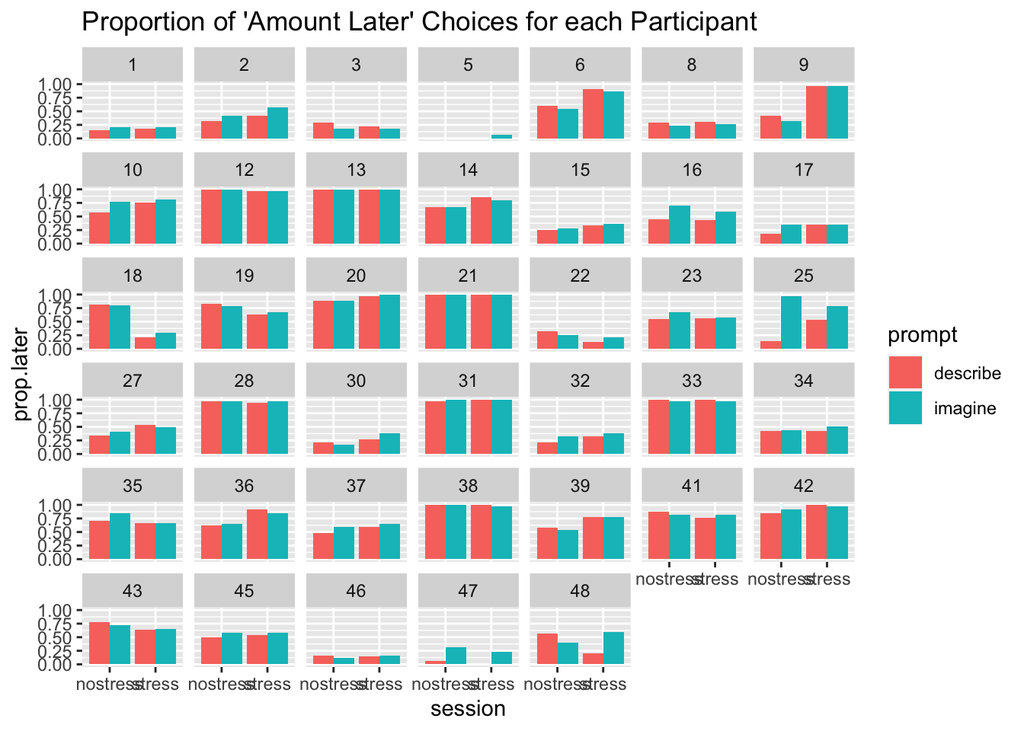

```r
# Small multiple plots for each of the 25 participants
ggplot(k_df, aes(fill=prompt, y=prop.later, x=session)) +
    geom_bar(position="dodge", stat="identity") +
  ggtitle("Proportion of 'Amount Later' Choices for each Participant") +
  facet_wrap(~subject)
```

```r
mean(k_df$prop.later[k_df$session=='stress'])
```

```
## [1] 0.6077093
```

```r
mean(k_df$prop.later[k_df$session=='nostress'])
```

```
## [1] 0.5730393
```

```r
mean(k_df$prop.later[k_df$prompt=='imagine'])
```

```
## [1] 0.6122781
```

```r
mean(k_df$prop.later[k_df$prompt=='describe'])
```

```
## [1] 0.5684706
```

```r
# take the mean across participants in a group
grouped.mean.proplater <- tapply(k_df$prop.later, list(as.factor(k_df$prompt), as.factor(k_df$session)), mean)
grouped.mean.proplater
```

```
##           nostress    stress
## describe 0.5510115 0.5859297
## imagine  0.5950672 0.6294889
```

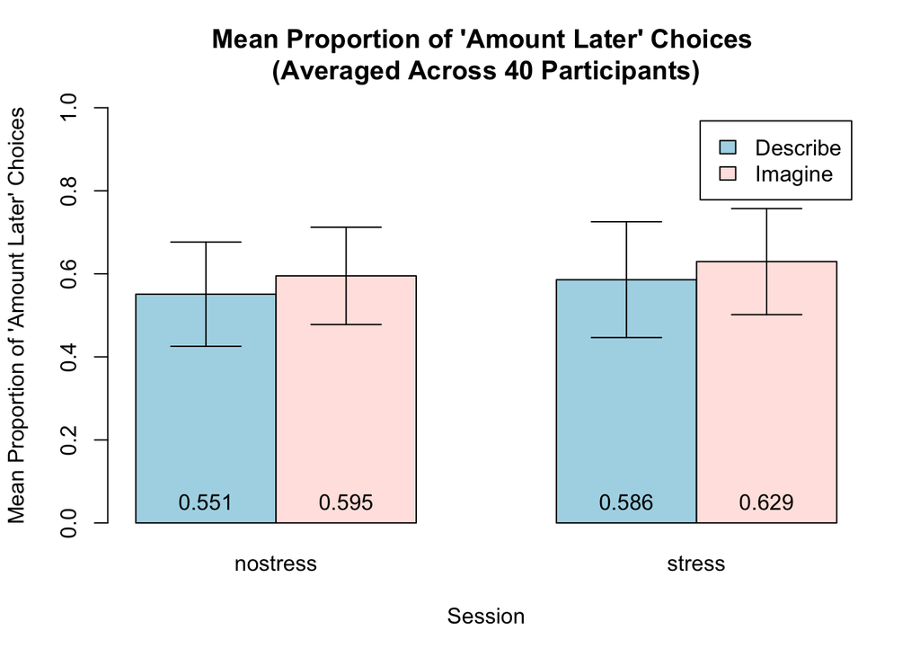

```r
# Remove 'between-subject variability'
## within each subject, calculate mean prop.later to average out the 4 sessions per subject
subject.mean.prop = tapply(k_df$prop.later, list(as.factor(k_df$subject)), mean)
sample.mean.prop = mean(k_df$prop.later)

# normalize prop.later within each subject
#prop.later.adj = prop.later - subject.mean + sample.mean
counter = 1
for (i in unique(k_df$subject)) {
  k_df$prop.later.adj[k_df$subject == i] = k_df$prop.later[k_df$subject == i] - subject.mean.prop[counter] + sample.mean.prop
  counter = counter + 1
}

# Create within-subject error bars
## standard deviation of adjusted prop.later
standard.deviation = tapply(k_df$prop.later.adj, list(as.factor(k_df$prompt), as.factor(k_df$session)), sd)

# get 4 standard errors for each Group
standard.error = (standard.deviation)/(sqrt(length(unique(k_df$subject))))
upper = grouped.mean.proplater + 1.96*(standard.error)
lower = grouped.mean.proplater - 1.96*(standard.error)

# this is the main part that plots the bar graph
bp.prop.later <- barplot2(grouped.mean.proplater, beside=TRUE,
      main="Mean Proportion of 'Amount Later' Choices \n(Averaged Across 40 Participants)",
      ylim=c(0,1), col=c("lightblue", "mistyrose"),
      plot.ci=TRUE, ci.u=upper, ci.l=lower,
      #names.arg = c("Stress Imagine", "Stress Describe", "Nostress Imagine", "Nostress Describe"),
      xlab="Session", ylab="Mean Proportion of 'Amount Later' Choices",
      legend=c("Describe","Imagine"))
      #args.legend=list(title="Prompt", x="topright", cex=.7))

text(bp.prop.later, 0, round(grouped.mean.proplater,3), cex=1, pos=3)
```

```r
# mathsd = tapply(k_df$prop.later, list(as.factor(k_df$prompt), as.factor(k_df$session)), sd)
# upper = grouped.mean + 1.96*(mathsd)
# lower = grouped.mean - 1.96*(mathsd)
```

## 4. Calculate k (discounting parameter)

Now let’s plot the k values for the four groups. For error bars, we want to make sure to plot within-subject error bars and not between-subjects.

Refer to this link for a step-by-step tutorial: http://www.cogsci.nl/blog/tutorials/156-an-easy-way-to-create-graphs-with-within-subject-error-bars

```r
# take the mean across participants in a group
grouped.mean.k <- tapply(k_df$k, list(as.factor(k_df$prompt), as.factor(k_df$session)), mean)
grouped.mean.k
```

```
##            nostress     stress
## describe 0.07452443 0.07178870
## imagine  0.04660146 0.02292162
```

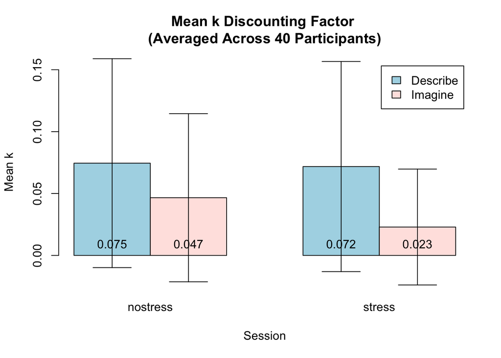

```r
# Remove 'between-subject variability'
## within each subject, calculate mean prop.later to average out the 4 sessions per subject
subject.mean.k = tapply(k_df$k, list(as.factor(k_df$subject)), mean)
sample.mean.k = mean(k_df$k)

# normalize prop.later within each subject
#k.adj = k - subject.mean + sample.mean
counter = 1
for (i in unique(k_df$subject)) {
  k_df$k.adj[k_df$subject == i] = k_df$k[k_df$subject == i] - subject.mean.k[counter] + sample.mean.k
  counter = counter + 1
}

# Create within-subject error bars
## standard deviation of adjusted prop.later
standard.deviation.k = tapply(k_df$k.adj, list(as.factor(k_df$prompt), as.factor(k_df$session)), sd)

# get 4 standard errors for each Group
standard.error = (standard.deviation.k)/(sqrt(length(unique(k_df$subject))))
upper = grouped.mean.k + 1.96*(standard.error)
lower = grouped.mean.k - 1.96*(standard.error)

# this is the main part that plots the bar graph
bp.k <- barplot2(grouped.mean.k, beside=TRUE,
      main="Mean k Discounting Factor \n(Averaged Across 40 Participants)",
      col=c("lightblue", "mistyrose"),
      plot.ci=TRUE, ci.u=upper, ci.l=lower,
      xlab="Session", ylab="Mean k",
      legend=c("Describe","Imagine"))

text(bp.k, 0, round(grouped.mean.k,3), cex=1, pos=3)
```

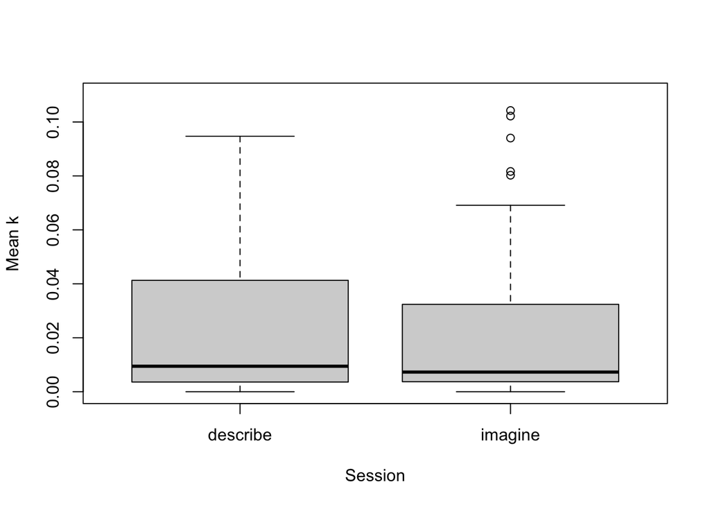

```r
boxplot(k_df$k ~ k_df$prompt, ylab = "Mean k", xlab = "Session", ylim=c(0,0.11))
```

```r
t.test(k_df[k_df$session == 'stress' & k_df$prompt == 'imagine',]$k, k_df[k_df$session == 'stress' & k_df$prompt == 'describe',]$k)
```

```
##
##  Welch Two Sample t-test
##
## data:  k_df[k_df$session == "stress" & k_df$prompt == "imagine", ]$k and k_df[k_df$session == "stress" & k_df$prompt == "describe", ]$k
## t = -1.3888, df = 40.994, p-value = 0.1724
## alternative hypothesis: true difference in means is not equal to 0
## 95 percent confidence interval:
##  -0.11992692  0.02219277
## sample estimates:
##  mean of x  mean of y
## 0.02292162 0.07178870
```

## 5. Restrict data to writeout-trials only: Calculate prop.later and k

Let’s start to restrict the data to see if any other patterns come up. What if we restricted the data to trials where participants are instructed to write out their responses (untimed), instead of simply thinking about it in their heads? Is there a change in the effect at all? Only include writeout trials (where writeout == 1).

Note that this is a much smaller trial sample because each participant had 12 writeout trials per session. Code not shown in Rmd output for simplicity.

Now that we’ve restricted the data to only take writeout trials, let’s plot prop.later (proportion of choices that were the AmountLater choice and not the $20 today).

```
##           nostress    stress
## describe 0.5591667 0.5433333
## imagine  0.5650000 0.6079167
```

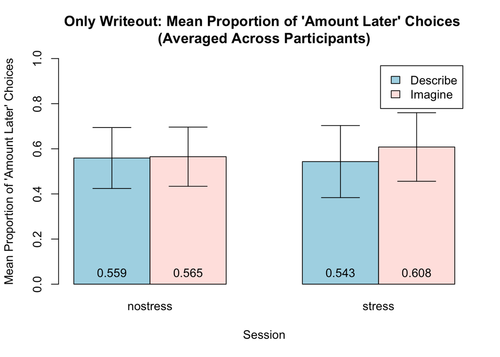

Likewise, now that we’ve restricted the data to only take writeout trials, let’s plot k (discounting parameter).

```
##           nostress    stress
## describe 0.1531808 0.1735704
## imagine  0.1129339 0.1688865
```

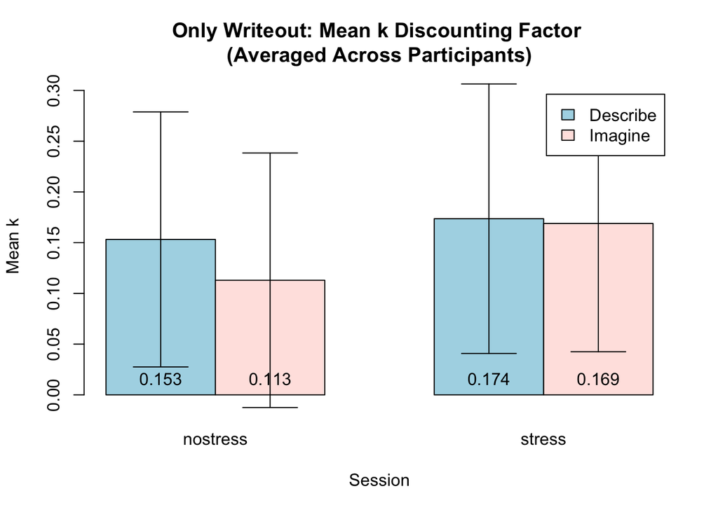

## 6. Model the data?

```r
#k.aov <- anova_test(data = k_df, dv = k, wid = subject, within = c(session, prompt))
#get_anova_table(k.aov)

k.aov <- aov(k ~ session*prompt, data = k_df)
summary(k.aov)
```

```
##                 Df Sum Sq Mean Sq F value Pr(>F)
## session          1  0.007 0.00698   0.229  0.633
## prompt           1  0.059 0.05897   1.938  0.166
## session:prompt   1  0.004 0.00439   0.144  0.705
## Residuals      156  4.747 0.03043
```

```r
# par(mfrow=c(2,2))
# plot(k.aov)
```

### Generalized Linear Mixed-Effects Model

- interaction logistic regression model; mixed effects model with random effects for interaction input is 1’s for choselater and 0’s for chosenow. binomial family (1 and 0). tend to not converge, but let’s test it anyway.

glmer(choice ~ session*imagine + (session*imagine | subject), data = bigdf, family=‘binomial’)

variables from bigdf: subject choselater (1,0) sessionlabel (stress, nostress) promptlabel (imagine, describe, NA)

```r
mod = glmer(choselater ~ sessionlabel*promptlabel + (sessionlabel*promptlabel | subject), data = bigdf, family='binomial')
```

```
## boundary (singular) fit: see ?isSingular
```

```r
summary(mod)
```

```
## Generalized linear mixed model fit by maximum likelihood (Laplace
##   Approximation) [glmerMod]
##  Family: binomial  ( logit )
## Formula:
## choselater ~ sessionlabel * promptlabel + (sessionlabel * promptlabel |
##     subject)
##    Data: bigdf
##
##      AIC      BIC   logLik deviance df.resid
##   5165.0   5257.1  -2568.5   5137.0     5292
##
## Scaled residuals:
##     Min      1Q  Median      3Q     Max
## -8.2061 -0.6050  0.1247  0.5965  4.9669
##
## Random effects:
##  Groups  Name                                  Variance Std.Dev. Corr
##  subject (Intercept)                           4.6777   2.1628
##          sessionlabelstress                    1.0628   1.0309    0.14
##          promptlabelimagine                    0.4340   0.6588   -0.18  0.14
##          sessionlabelstress:promptlabelimagine 0.3721   0.6100   -0.44 -0.57
##
##
##
##
##  -0.71
## Number of obs: 5306, groups:  subject, 40
##
## Fixed effects:
##                                       Estimate Std. Error z value Pr(>|z|)
## (Intercept)                             0.5387     0.3544   1.520   0.1285
## sessionlabelstress                      0.3692     0.2132   1.732   0.0833 .
## promptlabelimagine                      0.2682     0.1608   1.668   0.0953 .
## sessionlabelstress:promptlabelimagine  -0.1533     0.1960  -0.782   0.4342
## ---
## Signif. codes:  0 '***' 0.001 '**' 0.01 '*' 0.05 '.' 0.1 ' ' 1
##
## Correlation of Fixed Effects:
##             (Intr) sssnlb prmptl
## sssnlblstrs  0.001
## prmptlblmgn -0.239  0.260
## sssnlblstr: -0.116 -0.586 -0.676
## optimizer (Nelder_Mead) convergence code: 0 (OK)
## boundary (singular) fit: see ?isSingular
```

## 8. Analyze Questionnaire Results

In the task, we collected participants’ responses to a few questionnaires:

**Session 1:**

- Pre-task:
  - BFNE
  - PSS
  - State version of PANAS
  - State version of STAI
- Post-task:
  - Demographics questionnaire
  - State version of PANAS
  - State version of STAI

**Session 2:**

- Pre-task:
  - State version of PANAS
  - State version of STAI
- Post-task:
  - State version of PANAS
  - State version of STAI

### STAI Questionnaire

Are participants’ state anxiety levels actually affected by the TSST? To test this, we need to compare participants’ anxiety scores between Session 1 and Session 2.

```r
# ALL STAI QUESTIONNAIRES
stai_subdf <- bigdf[bigdf$ttype == 'stai-1' | bigdf$ttype == 'stai-2', ]
stai_responses <- stai_subdf$responses

# edit contents of the cell to just have numbers
stai_responses <- str_replace(stai_responses, "[}]", "") # replace last bracket with nothing
stai_responses_split <- noquote(strsplit(stai_responses, "\\,|\\:")) # split by commas and colons
stai_responses_flat <- as.numeric(unlist(noquote(strsplit(stai_responses, "\\,|\\:"))))
stai_responses_flat <- stai_responses_flat[c(FALSE, TRUE)] # removes every other False value (extract every other column / element)
# create data.frame
stai_scores <- data.frame(matrix(stai_responses_flat, nrow=length(stai_responses_split), byrow=TRUE))
# rename columns in df
colnames(stai_scores) <- c("stai_q1","stai_q2","stai_q3","stai_q4","stai_q5","stai_q6","stai_q7",
  "stai_q8","stai_q9","stai_q10","stai_q11","stai_q12","stai_q13","stai_q14","stai_q15",
  "stai_q16","stai_q17","stai_q18","stai_q19","stai_q20")
# +1 to each numeric value in the cell
stai_scores <- stai_scores + 1
# reverse 10 anxiety-absent items in desired columns
reverse_cols = c('stai_q1', 'stai_q2', 'stai_q5', 'stai_q8', 'stai_q10', 'stai_q11', 'stai_q15', 'stai_q16', 'stai_q19', 'stai_q20')
stai_scores[,reverse_cols] = 5 - stai_scores[ ,reverse_cols]

# calculate total sum of points
for (i in 1:nrow(stai_scores)) {
  stai_scores$total[i] <- sum(stai_scores[i,1:20])
}

# create stai_df dataframe
subject <- stai_subdf$subject[stai_subdf$ttype == 'stai-1']
session <- stai_subdf$sessionlabel[stai_subdf$ttype == 'stai-1']
pretask <- stai_scores$total[stai_subdf$ttype == 'stai-1']
posttask <- stai_scores$total[stai_subdf$ttype == 'stai-2']
diff <- posttask-pretask
stai_df <- data.frame(subject=c(subject), session=c(session), pretask=c(pretask), posttask=c(posttask), diff=c(diff))
#stai_df
```

- Black lines: these subjects had Nostress Session1, Stress Session2
- Gray lines: these subjects had Stress Session1, Nostress Session2

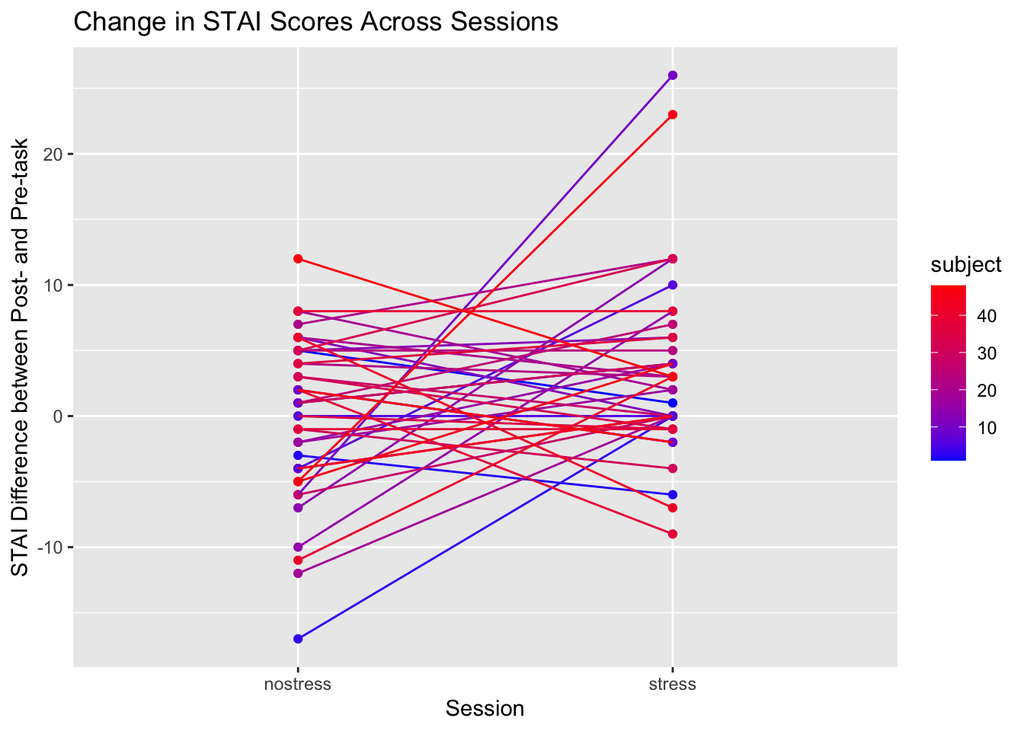

```r
# plot diff in stress vs. nostress
diff_stress <- stai_df$diff[stai_df$session == 'stress']
diff_nostress <- stai_df$diff[stai_df$session == 'nostress']
#plot(stai_df$session, stai_df$diff)

# Comparing Sessions
ggplot(stai_df, aes(x=as.factor(session), y=diff, color=subject)) +
  geom_point() +
  labs(y = "STAI Difference between Post- and Pre-task", x = "Session",
       title="Change in STAI Scores Across Sessions") +
  scale_color_gradient(low="blue", high="red") +
  geom_line(aes(group=interaction(subject))) #paired lines based on subject
```

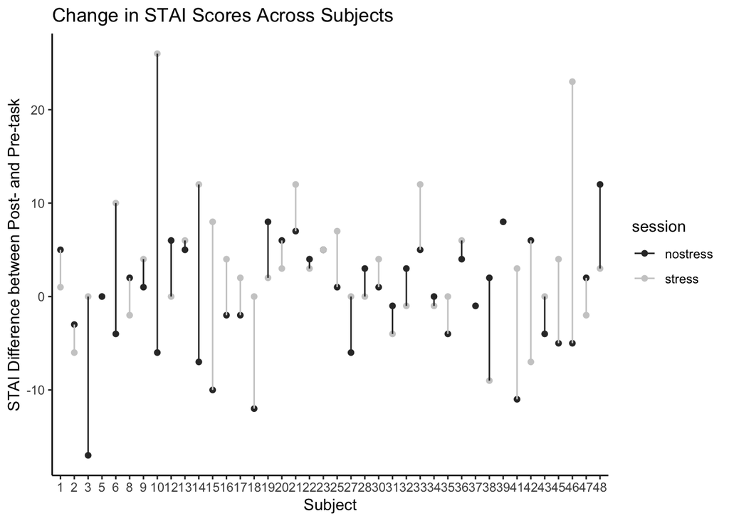

```r
# Comparing Subjects
ggplot(stai_df, aes(x=as.factor(subject), y=diff, color=session)) +
  geom_point() +
  labs(y = "STAI Difference between Post- and Pre-task", x = "Subject",
       title="Change in STAI Scores Across Subjects") +
  scale_color_grey() + theme_classic() +
  geom_line(aes(group=interaction(subject))) #paired lines based on subject
```

## 9. Restricting participants included in analyses

### Subset participants based on STAI scores

Identify the participants who were “actually” impacted by the TSST (according to change in STAI scores). This only includes participants whose STAI scores increased more during Stress sessions than during No-stress sessions.

From 40 total included participants, only 21 participants were impacted by the TSST (STAI scores increased more during Stress sessions than during No-stress sessions): [subject %in% c(10,13,14,15,16,17,18,21,25,27,3,30,33,35,36,41,43,45,46,6,9), ]

```r
stressed_subjects = vector()

for (s in unique(stai_df$subject)) {
  if (stai_df[stai_df$subject == s & stai_df$session == 'stress',]$diff > stai_df[stai_df$subject == s & stai_df$session == 'nostress',]$diff) {
    stressed_subjects = c(stressed_subjects, s)
  }
}

stressed_subjects
```

```
##  [1] 10 13 14 15 16 17 18 21 25 27  3 30 33 35 36 41 43 45 46  6  9
```

Let’s look at prop.later and k again, but only for the participants who were impacted by the TSST:

```r
k_df_valid <- k_df[k_df$subject %in% c(10,13,14,15,16,17,18,21,25,27,3,30,33,35,36,41,43,45,46,6,9), ]

# take the mean across participants in a group
grouped.mean.proplater <- tapply(k_df_valid$prop.later, list(as.factor(k_df_valid$prompt), as.factor(k_df_valid$session)), mean)
grouped.mean.proplater
```

```
##           nostress    stress
## describe 0.5518394 0.6192107
## imagine  0.6127106 0.6466807
```

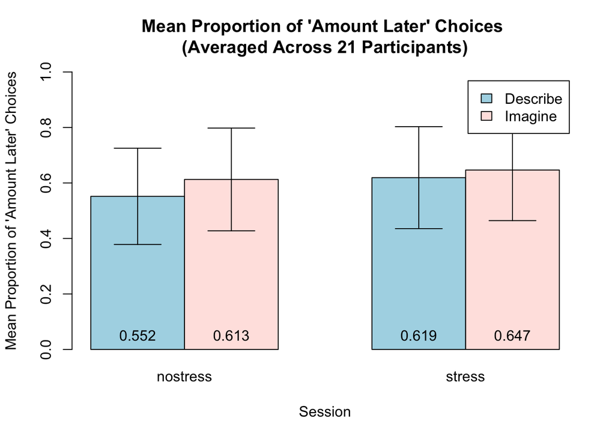

```r
# Remove 'between-subject variability'
## within each subject, calculate mean prop.later to average out the 4 sessions per subject
subject.mean = tapply(k_df_valid$prop.later, list(as.factor(k_df_valid$subject)), mean)
sample.mean = mean(k_df_valid$prop.later)

# normalize prop.later within each subject
#prop.later.adj = prop.later - subject.mean + sample.mean
counter = 1
for (i in unique(k_df_valid$subject)) {
  k_df_valid$prop.later.adj[k_df_valid$subject == i] = k_df_valid$prop.later[k_df_valid$subject == i] - subject.mean[counter] + sample.mean
  counter = counter + 1
}

# Create within-subject error bars
## standard deviation of adjusted prop.later
standard.deviation = tapply(k_df_valid$prop.later.adj, list(as.factor(k_df_valid$prompt), as.factor(k_df_valid$session)), sd)

# get 4 standard errors for each Group
standard.error = (standard.deviation)/(sqrt(length(unique(k_df_valid$subject))))
upper = grouped.mean.proplater + 1.96*(standard.error)
lower = grouped.mean.proplater - 1.96*(standard.error)

bp.prop.later <- barplot2(grouped.mean.proplater, beside=TRUE,
      main="Mean Proportion of 'Amount Later' Choices \n(Averaged Across 21 Participants)",
      ylim=c(0,1), col=c("lightblue", "mistyrose"),
      plot.ci=TRUE, ci.u=upper, ci.l=lower,
      #names.arg = c("Stress Imagine", "Stress Describe", "Nostress Imagine", "Nostress Describe"),
      xlab="Session", ylab="Mean Proportion of 'Amount Later' Choices",
      legend=c("Describe","Imagine"))
      #args.legend=list(title="Prompt", x="topright", cex=.7))

text(bp.prop.later, 0, round(grouped.mean.proplater,3), cex=1, pos=3)
```

```r
# take the mean across participants in a group
grouped.mean.k <- tapply(k_df_valid$k, list(as.factor(k_df_valid$prompt), as.factor(k_df_valid$session)), mean)
grouped.mean.k
```

```
##            nostress     stress
## describe 0.03015402 0.01852505
## imagine  0.02065226 0.01876406
```

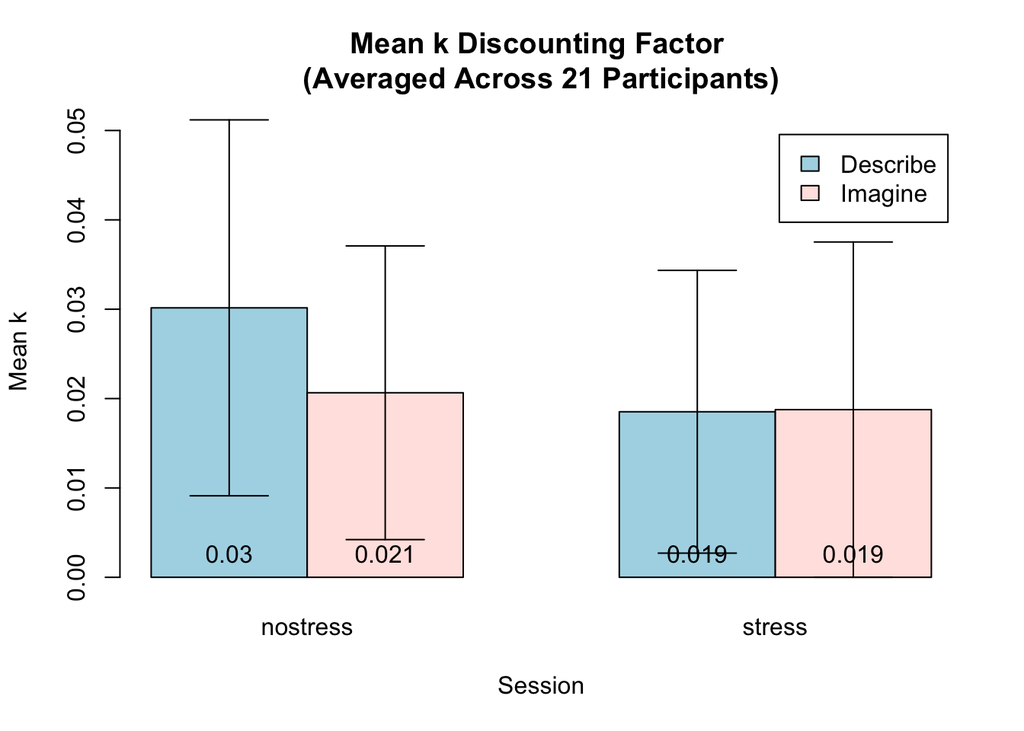

```r
# Remove 'between-subject variability'
## within each subject, calculate mean prop.later to average out the 4 sessions per subject
subject.mean = tapply(k_df_valid$k, list(as.factor(k_df_valid$subject)), mean)
sample.mean = mean(k_df_valid$k)

# normalize prop.later within each subject
#k.adj = k - subject.mean + sample.mean
counter = 1
for (i in unique(k_df_valid$subject)) {
  k_df_valid$k.adj[k_df_valid$subject == i] = k_df_valid$k[k_df_valid$subject == i] - subject.mean[counter] + sample.mean
  counter = counter + 1
}

# Create within-subject error bars
## standard deviation of adjusted prop.later
standard.deviation = tapply(k_df_valid$k.adj, list(as.factor(k_df_valid$prompt), as.factor(k_df_valid$session)), sd)

# get 4 standard errors for each Group
standard.error = (standard.deviation)/(sqrt(length(unique(k_df_valid$subject))))
upper = grouped.mean.k + 1.96*(standard.error)
lower = grouped.mean.k - 1.96*(standard.error)

bp.k <- barplot2(grouped.mean.k, beside=TRUE,
      main="Mean k Discounting Factor \n(Averaged Across 21 Participants)",
      col=c("lightblue", "mistyrose"),
      plot.ci=TRUE, ci.u=upper, ci.l=lower,
      xlab="Session", ylab="Mean k",
      legend=c("Describe","Imagine"))

text(bp.k, 0, round(grouped.mean.k,3), cex=1, pos=3)
```